# Introducing the Bivariate Data

# Introduction

Bivariate data refers to situations where you have one *quantitative* response variable and one *quantitative* explanatory variable. This requires a different approach to analysis and visualization.

By the end of this lesson, you should be able to:

1. Create scatterplots for 2 quantitative variables in base R and GGPlot
2. Describe what the correlation coefficient, $r$, quantifies
3. Calculate $r$ using the `cor()` function

Two datasets will be used to illustrate these concepts. The first contains self-reported confidence in mathematics and test scores. The second contains eruption duration and time between eruptions of Old Faithful geyser in Yellowstone National Park.

```r
# Load the libraries and data
library(tidyverse)
library(mosaic)
library(rio)

geyser <- import('https://byuistats.github.io/BYUI_M221_Book/Data/OldFaithful.xlsx')
names(geyser)
```

```
[1] "Duration" "Wait"     "Source"
```

```r
math <- import('https://byuistats.github.io/BYUI_M221_Book/Data/MathSelfEfficacy.xlsx')
names(math)
```

```
[1] "Gender"               "Score"                "ConfidenceRatingMean"
[4] "Comments"
```

```r
glimpse(geyser)
```

```
Rows: 272
Columns: 3
$ Duration <dbl> 3.600, 1.800, 3.333, 2.283, 4.533, 2.883, 4.700, 3.600, 1.950…
$ Wait     <dbl> 79, 54, 74, 62, 85, 55, 88, 85, 51, 85, 54, 84, 78, 47, 83, 5…
$ Source   <chr> "Azzalini, A. and Bowman, A. W. (1990).", "A look at some dat…
```

```r
glimpse(math)
```

```
Rows: 139
Columns: 4
$ Gender               <chr> "F", "F", "F", "F", "F", "F", "F", "F", "F", "F",…
$ Score                <dbl> 50.0, 83.3, 76.7, 50.0, 76.7, 73.3, 100.0, 96.7, …
$ ConfidenceRatingMean <dbl> 4.34, 4.73, 5.28, 2.83, 5.40, 4.03, 4.90, 5.93, 3…
$ Comments             <chr> "Shane Goodwin and other researchers studied fact…
```

# Correlation Coefficient

You may recall from algebra the expression

$$y=mx+b$$
That describes the functional form of a line with slope, $m$, and $y$-intercept, $b$. The slope could be positive or negative depending on the relationship between $x$ and $y$. A positive slope meant that as $x$ increases, $y$ also increases. A negative slope meant the opposite: as $x$ increases, $y$ decreases. The same can be true for 2 quantitative data measurements.

We say that 2 variables are “correlated” if as one variable changes, the other tends to change as well. However, the word “correlation” means something more than how we use the word “correlated” in everyday use.

**KEY DEFINITION**: Correlation is a mathematical quantity describing the *strength* and *direction* of a *linear* relationship between 2 quantitative variables.

The Correlation Coefficient is called $r$. It is a number between -1 and 1, with -1 being a perfect, negative correlation (ie. a straight line) and 1 being a perfect, positive correlation.

See the images below for scenarios for different correlation coefficients:

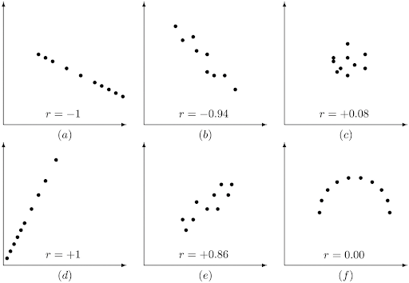

Notice the panel in the bottom right corner. There is clearly a perfect relationship between $x$ and $y$, yet $r=0$. This is because $r$ measures the strength and direction of a *linear* relationship. If the relationship is not linear, then $r$ can still be zero.

We check for linearity by observation of the scatterplots.

**Question**: What does the correlation coefficient, $r$, quantify? **Answer**: The correlation coefficient, r, quantifies for the relation between 2 quantitative variables.

**Question**: What does it mean if the correlation coefficient, $r$, is negative? **Answer**: If the correlation coefficient is negative, it means these 2 quantitative variables have a negative correlation. For example, as the x value goes up, the y value goes down as return.

# Math Confidence

## Scatter plot

Make a scatter plot showing the relationship between students’ self reported confidence rating and test score.

**Question**: Which variable is the Explanatory variable, $x$?  
**Answer**: The student confidence rating, which is the column ‘ConfidenceRatingMean’.

**Question**: Which is the Response variable, $y$?  
**Answer**: The math exam score, which is the column ‘Score’.

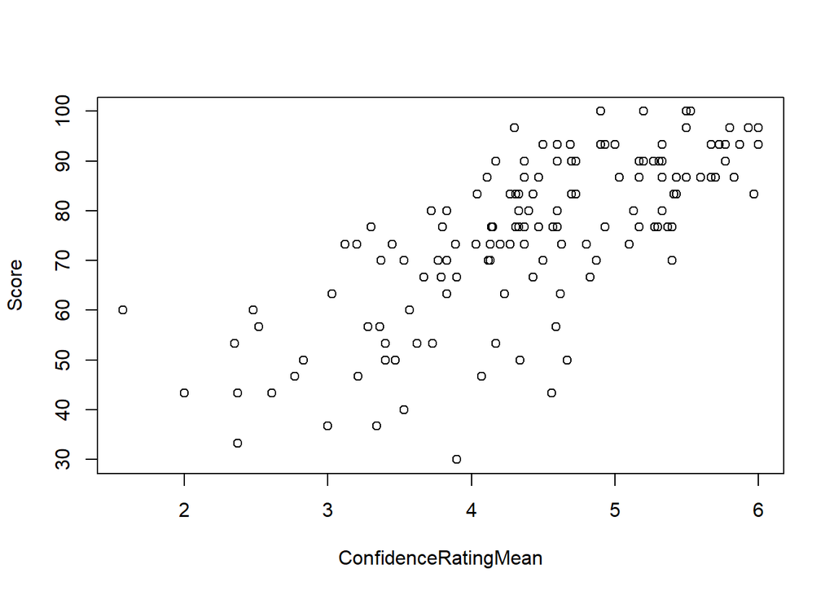

```r
# Base R
plot(Score ~ ConfidenceRatingMean, data = math)
```

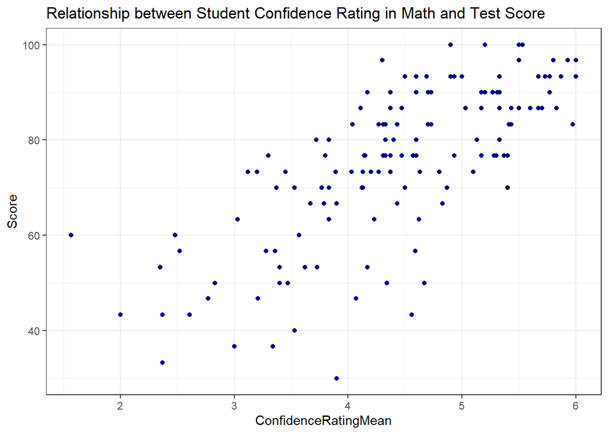

```r
# ggplot
ggplot(math, aes(x = ConfidenceRatingMean, y = Score )) +
  geom_point(color = "darkblue") + # Use geom_point() function to create point(dot) graph
  theme_bw() +
  labs(
    title = "Relationship between Student Confidence Rating in Math and Test Score"
  )
```

**Question**: Before calculating the Correlation Coefficient, r, describe in words the direction and strength of the relationship.  
**Answer**: The direction of the correlation between student confidence and the math test score, tends to be positive. The strength of the correlation, isn’t as strong as 1 but still good enough to identify the direction.

**Question**: What’s your best guess at, $r$ based on the scatterplot?  
**Answer**: I will guess 0.5

**Question**: Does it look linear?  
**Answer**: Yes.

Calculate the Correlation Coefficient, $r$:

```r
cor(Score ~ ConfidenceRatingMean, data = math)
```

```
[1] 0.7278648
```

**Question**: How far off was your guess?  
**Answer**: The correct r is 0.7278648 and my guess is 0.5. So, it’s not bad!

# Old Faithful

## Scatter plot

Make a scatter plot showing the relationship between wait time and the duration of the next eruption.

Which variable is the Explanatory variable? Which is the Response?

```r
glimpse(geyser)
```

```
Rows: 272
Columns: 3
$ Duration <dbl> 3.600, 1.800, 3.333, 2.283, 4.533, 2.883, 4.700, 3.600, 1.950…
$ Wait     <dbl> 79, 54, 74, 62, 85, 55, 88, 85, 51, 85, 54, 84, 78, 47, 83, 5…
$ Source   <chr> "Azzalini, A. and Bowman, A. W. (1990).", "A look at some dat…
```

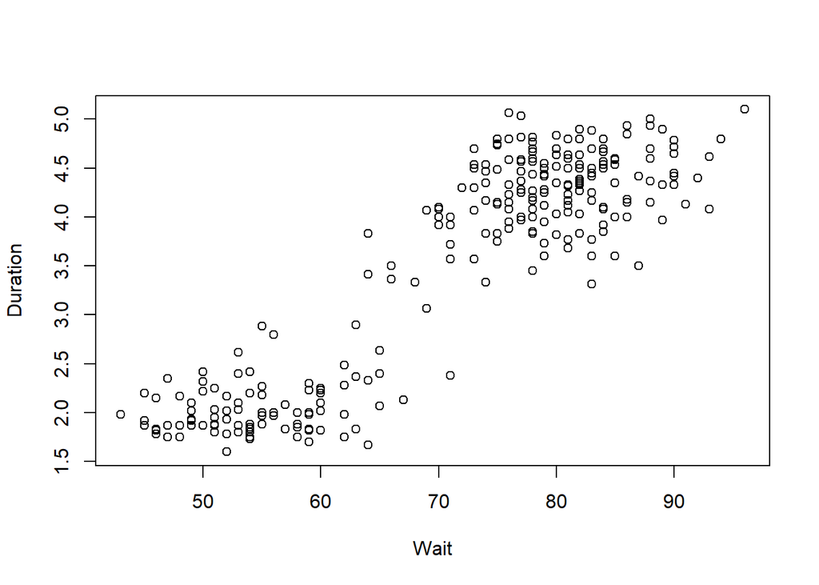

```r
# R plot
plot(Duration ~ Wait, data = geyser)
```

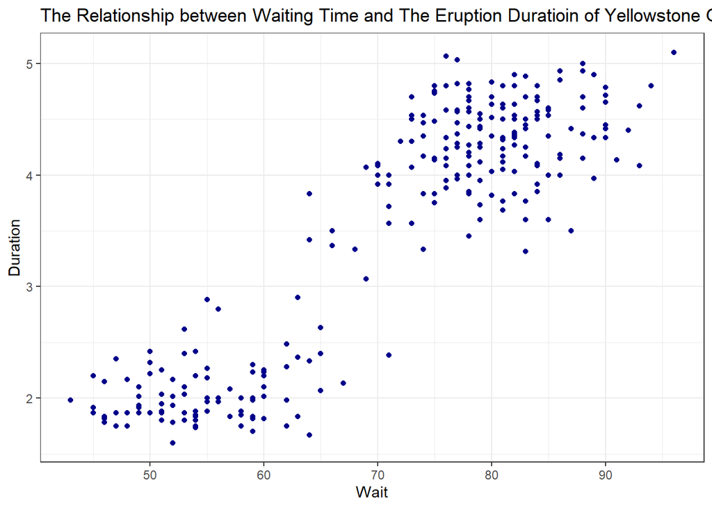

```r
# GGplot
ggplot(data = geyser, mapping = aes(x = Wait, y = Duration)) +
  geom_point(color = "darkblue") + # Use color to change the color of point (dot)
  theme_bw() + # Remember to put the () behind the theme_bw
  labs(title = "The Relationship between Waiting Time and The Eruption Duratioin of Yellowstone Geyser")
```

**Question**: Before calculating the Correlation Coefficient, r, describe in words the direction and strength of the relationship.  
**Answer**: The direction of the correlation between Wait and Duration tends to be positive. The strength of the relationship is strong enough to recognize it’s a positive correlation.

**Question**: What’s your best guess at, $r$ based on the scatterplot?  
**Answer**: My guess is 0.73

**Question**: Does it look linear?  
**Answer**: Yes

Calculate the Correlation Coefficient, $r$:

```r
cor(Duration ~ Wait, data = geyser)
```

```
[1] 0.9008112
```

**Question**: How far off was your guess?  
**Answer**: The correct correlation coefficient, r, is 0.9008112. My guess is 0.73, so it’s not bad!